# Machine Learning Coursera Project

huangk3

June 12, 2015

### Background

Using devices such as Jawbone Up, Nike FuelBand, and Fitbit it is now possible to collect a large amount of data about personal activity relatively inexpensively. These type of devices are part of the quantified self movement – a group of enthusiasts who take measurements about themselves regularly to improve their health, to find patterns in their behavior, or because they are tech geeks. One thing that people regularly do is quantify how much of a particular activity they do, but they rarely quantify how well they do it. In this project, your goal will be to use data from accelerometers on the belt, forearm, arm, and dumbell of 6 participants. They were asked to perform barbell lifts correctly and incorrectly in 5 different ways. More information is available from the website here: http://groupware.les.inf.puc-rio.br/har (see the section on the Weight Lifting Exercise Dataset). The goal of the project is to predict the manner in which people did the exercise.

### Data Preparation

Download and load the dataset for training and testing respectively.

```r
download.file("https://d396qusza40orc.cloudfront.net/predmachlearn/pml-training.csv" , 'training.csv', method="curl")
download.file("https://d396qusza40orc.cloudfront.net/predmachlearn/pml-testing.csv" , 'testing.csv', method="curl")
trainset<-read.csv("training.csv", header=T)
testset<-read.csv("testing.csv", header=T)
```

```r
dim(trainset)
```

```
## [1] 19622   160
```

```r
dim(testset)
```

```
## [1]  20 160
```

The training dataset contains 19622 observations and 160 variables, while the testing dataset has 20 observations and 160 variables.

```r
library(caret)
trainset_a<-trainset[, nearZeroVar(trainset, saveMetrics=TRUE)$nzv!=TRUE]
trainset_cleaned<-trainset_a[, colSums(is.na(trainset_a))<0.5*dim(trainset_a)[1]]
```

Further exclude the variables which would unlikely contribute to the outcome.

```r
trainset_cleaned<-trainset_cleaned[, !grepl("^X|name|timestamp|window", names(trainset_cleaned))]
```

Subset the testing dataset to make it has the same variabls as the training set.

```r
testset_cleaned<-testset[, names(trainset_cleaned[, -length(trainset_cleaned)])]
```

Check if there are any missing value in the cleaned training dataset or testing dataset.

```r
sum(complete.cases(trainset_cleaned))==nrow(trainset_cleaned)
```

```
## [1] TRUE
```

```r
sum(complete.cases(testset_cleaned))==nrow(testset_cleaned)
```

```
## [1] TRUE
```

The dataset looks complete, we can use them to build the predictive model.

## Slice the Training Dataset

Using the “createDataPartition” function of the “caret” package, we split the cleaned training dataset into the train/test group.

```r
set.seed(150612) # For reproducibile purpose
intrain<-createDataPartition(trainset_cleaned$classe, p=0.75, list=F)
TrainData<-trainset_cleaned[intrain, ]
TestData<-trainset_cleaned[-intrain, ]
```

## Explore the Training Dataset

Visualize the correlation matrix of the “train”" dataset

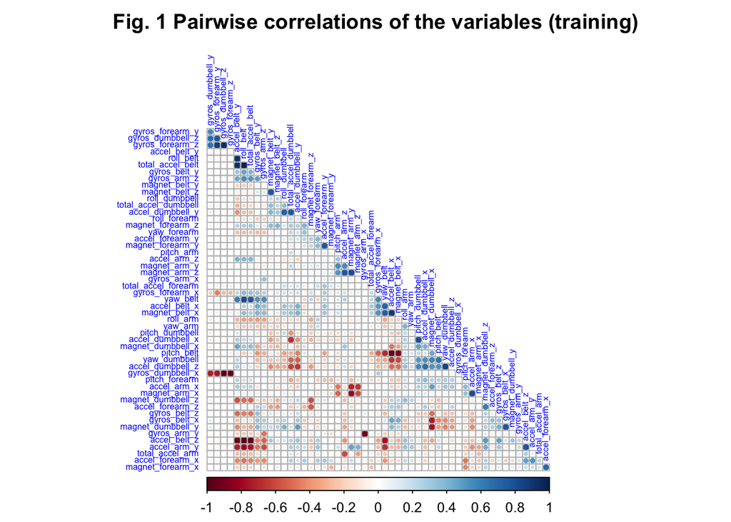

```r
library(corrplot)
corrplot(corr=cor(TrainData[, -length(TrainData)]), method = "circle", order="hclust", type='lower', tl.cex=0.5,mar=c(0,2,2,1), tl.col='blue',tl.pos='ld', diag=F, title="Fig. 1 Pairwise correlations of the variables (training)")
```

## Data Modeling

We selected Random Forest algorithm to buld the prediction model because of its accuracy and robustness to correlated covariates & outliers in general, and we’ll use ten-fold for the algorithm cross validation.

```r
rfModel<-train(classe~., data=TrainData, method="rf",trControl=trainControl(method="repeatedcv", number=10, repeats=3), ntree=100)
pred_test<-predict(rfModel, newdata=TestData)
confusionMatrix(TestData$classe, pred_test)
```

```
## Confusion Matrix and Statistics
##
##           Reference
## Prediction    A    B    C    D    E
##          A 1393    2    0    0    0
##          B    9  940    0    0    0
##          C    0   11  844    0    0
##          D    0    0   13  791    0
##          E    0    0    0    2  899
##
## Overall Statistics
##
##                Accuracy : 0.9925
##                  95% CI : (0.9896, 0.9947)
##     No Information Rate : 0.2859
##     P-Value [Acc > NIR] : < 2.2e-16
##
##                   Kappa : 0.9905
##  Mcnemar's Test P-Value : NA
##
## Statistics by Class:
##
##                      Class: A Class: B Class: C Class: D Class: E
## Sensitivity            0.9936   0.9864   0.9848   0.9975   1.0000
## Specificity            0.9994   0.9977   0.9973   0.9968   0.9995
## Pos Pred Value         0.9986   0.9905   0.9871   0.9838   0.9978
## Neg Pred Value         0.9974   0.9967   0.9968   0.9995   1.0000
## Prevalence             0.2859   0.1943   0.1748   0.1617   0.1833
## Detection Rate         0.2841   0.1917   0.1721   0.1613   0.1833
## Detection Prevalence   0.2845   0.1935   0.1743   0.1639   0.1837
## Balanced Accuracy      0.9965   0.9920   0.9911   0.9972   0.9998
```

From the result we found that the accuracy is 0.992, Kappa is 0.99.

## Out of Sample Error Rate

```r
OSE<-1-as.numeric(confusionMatrix(TestData$classe, pred_test)$overall[1])
```

The out of sample error is 0.008.

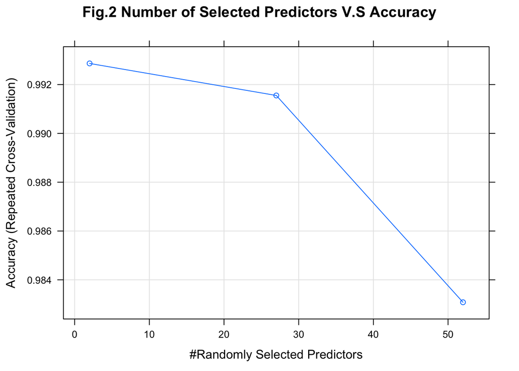

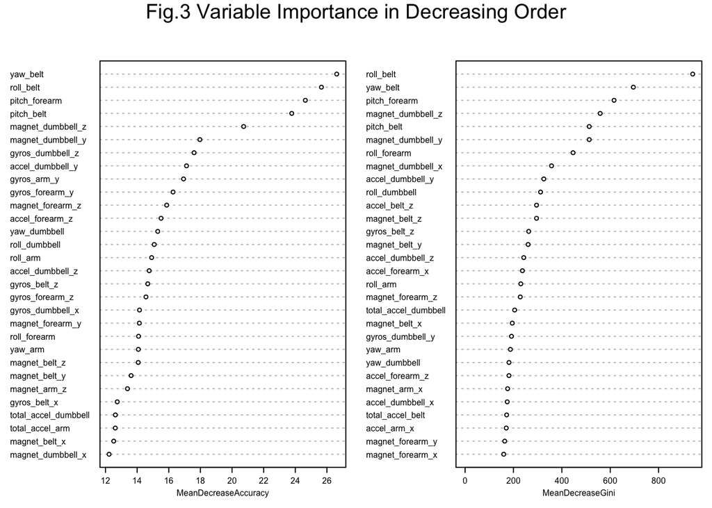

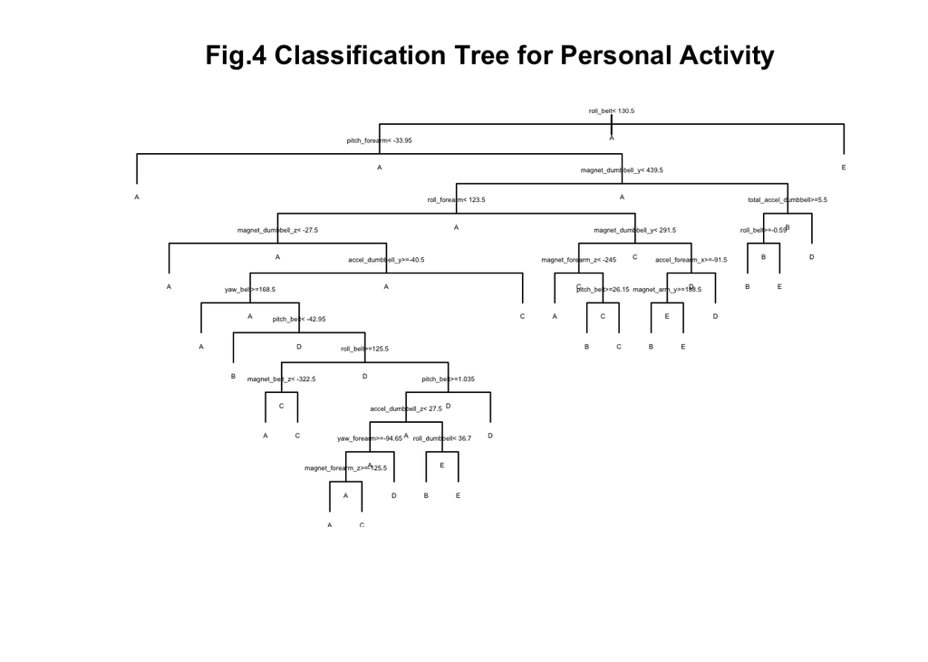

## Prediction for Test Dataset

Apply the model to the original testing data set downloaded from the data source.

```r
predict(rfModel, testset_cleaned)
```

```
##  [1] B A B A A E D B A A B C B A E E A B B B
## Levels: A B C D E
```